# LAGOS Spatial Analysis

Anna Marshall

23 February, 2022

# Overview

As mentioned in part 1, LAGOS is a multi-scaled geospatial and temporal database of lake ecological context and water quality for thousands of US lakes. LAGOS-NE contains data for 51,101 lakes and reservoirs larger than 4 ha in 17 lake-rich US states. The database includes 3 data modules for: lake location and physical characteristics, ecological context, and in situ measurements of lake water quality. This database is one of the largest and most comprehensive databases of its type because it includes both in situ measurements and ecological context data. You can use the link to learn more about LAGOS. (https://lagoslakes.org/)

# Methods

In this part of the assignment, we’re diving one step deeper into the LAGOS data and are looking at the in site measurements of lake water quality. We will use secchi disk and chlorophyll data for analyses.

# Analysis

## 1) What is the correlation between Secchi Disk Depth and Chlorophyll a for sites with at least 200 observations?

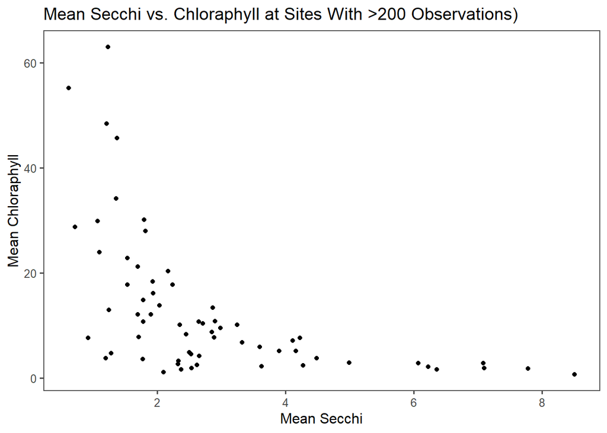

```r
mean_spatial %>%
ggplot(aes(x=mean_secchi,y=mean_chl))+
  geom_point()+
  labs(title="Mean Secchi vs. Chloraphyll at Sites With >200 Observations)",x="Mean Secchi",y="Mean Chloraphyll")+
  ggthemes::theme_few()
```

## 2) What states have the most data?

Minnesota has the most data followed by Michigan. Rhode Island has the least amount of available data.

### 2a) First you will need to make a lagos spatial dataset that has the total

number of counts per site.

```r
site_counts2 <- lake_centers %>%
  group_by(lagoslakeid) %>%
  mutate(count = n()) %>%
  select(lagoslakeid,nhd_long,nhd_lat, count, state_zoneid)

states_lagos <- lagos$state %>%
  select(-state_pct_in_nwi, -state_ha_in_nwi,-state_ha)

stateid_counts2 <- inner_join(site_counts2, states_lagos, by="state_zoneid")

state_sums2 <- stateid_counts2 %>%
  group_by(state_name) %>%
  summarize(sum_counts = sum(count))
states <- us_states()
states_join2 <- inner_join(states,state_sums2,by='state_name') %>%
  arrange(desc(sum_counts))
```

### 2b) Second, you will need to join this point dataset to the us_boundaries

data.

```r
mapview(states_join2, zcol='sum_counts')
```

[interactive chart not shown]

### 2c) Then you will want to group by state and sum all the observations in that

state and arrange that data from most to least total observations per state.

```r
states_join2 <- inner_join(states,state_sums2,by='state_name') %>%
  arrange(desc(sum_counts))
state_count_table<-tibble(states_join2)
state_count_table %>% select(state_name,sum_counts)
```

```
## # A tibble: 17 x 2
##    state_name    sum_counts
##    <chr>              <int>
##  1 Minnesota          29022
##  2 Michigan           15569
##  3 Wisconsin          13790
##  4 New York           11950
##  5 Illinois           11805
##  6 Missouri            9116
##  7 Indiana             7942
##  8 Ohio                6120
##  9 Pennsylvania        5922
## 10 Maine               5518
## 11 Iowa                4636
## 12 Massachusetts       3912
## 13 New Jersey          3333
## 14 New Hampshire       2544
## 15 Connecticut         2025
## 16 Vermont             1626
## 17 Rhode Island         618
```

## 3) Is there a spatial pattern in Secchi disk depth for lakes with at least 200

observations?

The places with the most and least lake data had high concentrations of low depths. I see what appears to be greater secchi disk depths in larger lakes, but that pattern is strictly visual. There does not appear to be a spatial pattern in geographic location of the lakes other than the lakes in New England appear to be slightly clearer based on the secchi depth.

```r
mapview(mean_spatial,zcol='mean_secchi')
```

[interactive chart not shown]